# Mission Python Project: Luke Reid

### Note: I will find the inconsistencies in the string columns first, and then find the inconsistencies in the numerical columns separately.

```python
# I will now look for inconsistencies in the data by determining which columns contain unexpected values
# I will ensure that the columns containing strings are what I expect them to be
# e.g. the sex column should only contain values "male" and "female",
# not "m" and "f" or any other type of string

# Here I define what values I deem to be "expected"
expected_sex_values = ['male', 'female']
expected_smoker_values = ['yes', 'no']
expected_region_values = ['northeast', 'northwest', 'southeast', 'southwest']
expected_broker_name = ["Broker A","Broker B","Broker C","Broker D"]

# Finds rows with unexpected values - these are any rows that are not "expected"
unexpected_sex = df[~df['sex'].isin(expected_sex_values)]
unexpected_smoker = df[~df['smoker'].isin(expected_smoker_values)]
unexpected_region = df[~df['region'].isin(expected_region_values)]

# I now display the rows containing unexpected strings
print("Rows with unexpected 'sex' values:\n", unexpected_sex)
print("Rows with unexpected 'smoker' values:\n", unexpected_smoker)
print("Rows with unexpected 'region' values:\n", unexpected_region)

# The print display says "Empty DataFrame" for each column containg strings
# this means that there are no "unexpected" values in the string columns
```

```
Rows with unexpected 'sex' values:
 Empty DataFrame
Columns: [broker name, age, sex, bmi, children, smoker, region, claims incurred]
Index: []
Rows with unexpected 'smoker' values:
 Empty DataFrame
Columns: [broker name, age, sex, bmi, children, smoker, region, claims incurred]
Index: []
Rows with unexpected 'region' values:
 Empty DataFrame
Columns: [broker name, age, sex, bmi, children, smoker, region, claims incurred]
Index: []
```

```python
# I will now check to see if there are any anomolies in the table - I want to make sure that all of the numerical
# values are realistic

# For example: Based on my research, the oldest person currently alive is 116 years old
# Therefore, there should not be any ages above 116

# Similarly, the greatest number of children birthed from one mother in the 21st Century is 22 children, therefore
# I do not expect any of the values in the "children" column to be greater than this.

# In addition,a BMI of 30 is considered obese, therefore it would be very abnormal to see a BMI of say 50.

# Claims incurred should only be >= 0 as it is a monetary figure: I don't expect to see any negative figures.

# Based on these factors, I define my "realistic" values/ranges.



# I first define "realistic" values for each column

# Checks the 'age' column for unrealistic values
unexpected_age = df[~df['age'].between(0, 100)]

# Checks the 'bmi' column for unrealistic values
unexpected_bmi = df[~df['bmi'].between(10.0, 50.0)]

# Checks the 'children' column for unrealistic values
unexpected_children = df[~df['children'].between(0, 10)]


# Checks the 'claims incurred' column for unrealistic values
unexpected_claims = df[df['claims incurred'].lt(0)]



# Combines all of the unexpected records in the DataFrame
unexpected_df = pd.concat([unexpected_age, unexpected_bmi, unexpected_children, unexpected_claims]).drop_duplicates()

# This print identifies the rows with unexpected numerical data values
print(unexpected_df)

# From this print display, I can see that the unexpected numerical values occur in rows 0,1,2,293 and 1050
```

```
     broker name  age     sex    bmi  children smoker     region  \
293     Broker C  295  female  39.60         0    yes  northwest
0       Broker D   18    male  53.13         0     no  southeast
1       Broker A   22    male  52.58         1    yes  southeast
2       Broker B   23    male  50.38         1     no  southeast
1050    Broker D   45  female  25.70         3     no  southwest

      claims incurred
293          29260.00
0             1163.46
1            44501.40
2             2438.06
1050         -9101.00
```

```python
# I will now remove all of the rows containing these unrealistic/unexpected numerical values
df = df.drop([293, 0, 1, 2, 1050])

# Since I have removed indices 0,1 and 2 from the DataFrame (my DataFrame now begins at index 3),
# I will re-index my DataFrame so that it begins from 0 once again
df = df.reset_index(drop=True)

#I now print my DataFrame to ensure that the re-indexing was successful.
print(df)
```

```
     broker name  age     sex     bmi  children smoker     region  \
0       Broker A   58    male  49.060         0     no  southeast
1       Broker C   46  female  48.070         2     no  northeast
2       Broker B   52    male  47.740         1     no  southeast
3       Broker C   37  female  47.600         2    yes  southwest
4       Broker A   47    male  47.520         1     no  southeast
...          ...  ...     ...     ...       ...    ...        ...
1327    Broker A   28  female  17.290         0     no  northeast
1328    Broker A   26  female  17.195         2    yes  northeast
1329    Broker A   21  female  16.815         1     no  northeast
1330    Broker B   38    male  16.815         2     no  northeast
1331    Broker B   18    male  15.960         0     no  northeast

      claims incurred
0            11381.33
1             9432.93
2             9748.91
3            46113.51
4             8083.92
...               ...
1327          3732.63
1328         14455.64
1329          3167.46
1330          6640.54
1331          1694.80

[1332 rows x 8 columns]
```

```python
# My data set should now be competely clean
```

```python
# I will now do some statistical analysis
# However, if printed straight-away, the numbers will be given to 6.d.p, which I found difficult to read. Therefore,
# I have written a code that will temporarily change the print to 2.d.p - just when viewing the descriptive statistics

#Sets the print to 2.d.p
pd.set_option('precision', 2)

# This gives the count, mean, standard deviation, minimum, maximum, and quartiles for each column in the DataFrame
print(df.describe())

# This gives the correlation between the numerical columns i.e. age and children
print(df.corr())

# This counts the number of times each broker name appeared
broker_counts = df['broker name'].value_counts()
print(broker_counts)


# This resets the number of decimal places back to default
pd.reset_option('precision')

# The first table contains the count, mean, standard deviation, minimum, maximum, and quartiles for each column
# The second table displays the correlation between pairs of the column data

#The correlation coefficient is always between -1 and 1, so I can confirm that the code has worked.
```

```
           age      bmi  children  claims incurred
count  1332.00  1332.00   1332.00          1332.00
mean     39.25    30.62      1.09         13279.10
std      14.05     6.03      1.21         12094.47
min      18.00    15.96      0.00          1121.87
25%      27.00    26.27      0.00          4744.32
50%      39.00    30.33      1.00          9401.17
75%      51.00    34.62      2.00         16687.37
max      64.00    49.06      5.00         63770.43
                  age   bmi  children  claims incurred
age              1.00  0.12      0.04             0.30
bmi              0.12  1.00      0.02             0.20
children         0.04  0.02      1.00             0.07
claims incurred  0.30  0.20      0.07             1.00
Broker A    344
Broker B    344
Broker D    325
Broker C    319
Name: broker name, dtype: int64
```

## Key statistics and insights that I've have gained from the data.

#### Correlation: There's a positive correlation coefficient of 0.3 between 'age' and 'claims incurred' indicating that as the age of individuals increases, the claim amounts also increases. However, this is a weak correlation, as 0.3 is close to 0. The correlations between other variables are even weaker.

```python
# I will now convert the DataFrame into a csv file, so that I can import it into Power BI for data visualisation
# I've done this by creating a new folder in my Jupyter Notebook called "Mission File Complete", and then saving the csv
# file to this directory
#df.to_csv('Mission File Complete/MissionUK_LukeReid.csv', index=False)
```

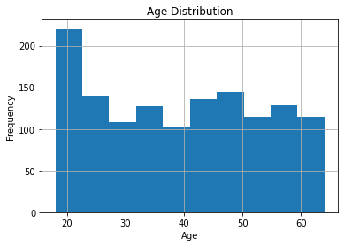

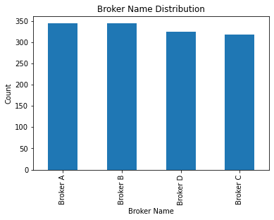

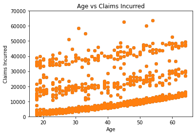

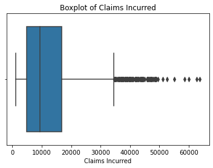

```python
import matplotlib.pyplot as plt
import seaborn as sns

# Histogram
df['age'].hist()
plt.title('Age Distribution')
plt.xlabel('Age')
plt.ylabel('Frequency')
plt.show()

# Bar plot
df['broker name'].value_counts().plot(kind='bar')
df['broker name'].value_counts().plot(kind='bar')
plt.title('Broker Name Distribution')
plt.xlabel('Broker Name')
plt.ylabel('Count')
plt.show()

# Scatter plot
plt.scatter(df['age'], df['claims incurred'])
plt.scatter(df['age'], df['claims incurred'])
plt.title('Age vs Claims Incurred')
plt.xlabel('Age')
plt.ylabel('Claims Incurred')
plt.ylim(0, 70000)
plt.show()

# Box plot
sns.boxplot(x=df['claims incurred'])
plt.title('Boxplot of Claims Incurred')
plt.xlabel('Claims Incurred')
plt.show()
```

```python
df_encoded = pd.get_dummies(df, columns=['broker name', 'sex', 'smoker', 'region'])
df_encoded
```

|  | age | bmi | children | claims incurred | broker name_Broker A | broker name_Broker B | broker name_Broker C | broker name_Broker D | sex_female | sex_male | smoker_no | smoker_yes | region_northeast | region_northwest | region_southeast | region_southwest |
| --- | --- | --- | --- | --- | --- | --- | --- | --- | --- | --- | --- | --- | --- | --- | --- | --- |
| 0 | 58 | 49.060 | 0 | 11381.33 | 1 | 0 | 0 | 0 | 0 | 1 | 1 | 0 | 0 | 0 | 1 | 0 |
| 1 | 46 | 48.070 | 2 | 9432.93 | 0 | 0 | 1 | 0 | 1 | 0 | 1 | 0 | 1 | 0 | 0 | 0 |
| 2 | 52 | 47.740 | 1 | 9748.91 | 0 | 1 | 0 | 0 | 0 | 1 | 1 | 0 | 0 | 0 | 1 | 0 |
| 3 | 37 | 47.600 | 2 | 46113.51 | 0 | 0 | 1 | 0 | 1 | 0 | 0 | 1 | 0 | 0 | 0 | 1 |
| 4 | 47 | 47.520 | 1 | 8083.92 | 1 | 0 | 0 | 0 | 0 | 1 | 1 | 0 | 0 | 0 | 1 | 0 |
| ... | ... | ... | ... | ... | ... | ... | ... | ... | ... | ... | ... | ... | ... | ... | ... | ... |
| 1327 | 28 | 17.290 | 0 | 3732.63 | 1 | 0 | 0 | 0 | 1 | 0 | 1 | 0 | 1 | 0 | 0 | 0 |
| 1328 | 26 | 17.195 | 2 | 14455.64 | 1 | 0 | 0 | 0 | 1 | 0 | 0 | 1 | 1 | 0 | 0 | 0 |
| 1329 | 21 | 16.815 | 1 | 3167.46 | 1 | 0 | 0 | 0 | 1 | 0 | 1 | 0 | 1 | 0 | 0 | 0 |
| 1330 | 38 | 16.815 | 2 | 6640.54 | 0 | 1 | 0 | 0 | 0 | 1 | 1 | 0 | 1 | 0 | 0 | 0 |
| 1331 | 18 | 15.960 | 0 | 1694.80 | 0 | 1 | 0 | 0 | 0 | 1 | 1 | 0 | 1 | 0 | 0 | 0 |

1332 rows × 16 columns

```python
from sklearn.model_selection import train_test_split

# Define the feature matrix X and the target variable y
X = df_encoded.drop('claims incurred', axis=1)
y = df_encoded['claims incurred']
```

```python
from sklearn.compose import ColumnTransformer
from sklearn.preprocessing import OneHotEncoder, StandardScaler

# Define the preprocessing steps
categorical_cols = X.select_dtypes(include=['object', 'bool']).columns
numerical_cols = X.select_dtypes(include=['int64', 'float64']).columns

# Create the preprocessors
categorical_transformer = OneHotEncoder(drop='first')
numerical_transformer = StandardScaler()

# Combine the preprocessors
preprocessor = ColumnTransformer(
    transformers=[
        ('num', numerical_transformer, numerical_cols),
        ('cat', categorical_transformer, categorical_cols)])

# Split the data into a training set and a test set
X_train, X_test, y_train, y_test = train_test_split(X, y, test_size=0.2, random_state=42)

# Fit the preprocessor on the training data and transform the training data
X_train_preprocessed = preprocessor.fit_transform(X_train)

# Transform the test data
X_test_preprocessed = preprocessor.transform(X_test)
```

```python
from sklearn.linear_model import LinearRegression

# Create a linear regression model
model = LinearRegression()

# Train the model
model.fit(X_train, y_train)

# Make predictions on the test set
y_pred = model.predict(X_test)

from sklearn.metrics import mean_squared_error, mean_absolute_error, r2_score

# Compute the metrics
mse = mean_squared_error(y_test, y_pred)
rmse = np.sqrt(mse)
mae = mean_absolute_error(y_test, y_pred)
r2 = r2_score(y_test, y_pred)

# Print the metrics
print(f'MSE: {mse}')
print(f'RMSE: {rmse}')
print(f'MAE: {mae}')
print(f'R^2: {r2}')
```

```
MSE: 42202536.99042587
RMSE: 6496.34797331746
MAE: 4533.998480840427
R^2: 0.7335896330266442
```

```python
from sklearn.compose import ColumnTransformer
from sklearn.preprocessing import OneHotEncoder, StandardScaler

# Define which columns are categorical and which are numerical
categorical_cols = X.select_dtypes(include=['object', 'bool']).columns
numerical_cols = X.select_dtypes(include=['int64', 'float64']).columns

# Create the preprocessors
categorical_transformer = OneHotEncoder(drop='first', handle_unknown='ignore')
numerical_transformer = StandardScaler()

# Combine the preprocessors
preprocessor = ColumnTransformer(
    transformers=[
        ('num', numerical_transformer, numerical_cols),
        ('cat', categorical_transformer, categorical_cols)])

# Fit and transform the training data
X_train_preprocessed = preprocessor.fit_transform(X_train)

# Transform the test data
X_test_preprocessed = preprocessor.transform(X_test)

from sklearn.tree import DecisionTreeRegressor
from sklearn.metrics import mean_squared_error, mean_absolute_error, r2_score

# Create a decision tree regressor
model = DecisionTreeRegressor(random_state=42)

# Train the model
model.fit(X_train_preprocessed, y_train)

# Make predictions on the test set
y_pred = model.predict(X_test_preprocessed)

# Compute the metrics
mse = mean_squared_error(y_test, y_pred)
rmse = np.sqrt(mse)
mae = mean_absolute_error(y_test, y_pred)
r2 = r2_score(y_test, y_pred)

# Print the metrics
print(f'MSE: {mse}')
print(f'RMSE: {rmse}')
print(f'MAE: {mae}')
print(f'R^2: {r2}')
```

```
MSE: 268545538.6654596
RMSE: 16387.359111994207
MAE: 11879.210983948635
R^2: -0.6952373152626592
```

```python
from sklearn.ensemble import RandomForestRegressor

# Create a random forest regressor
model = RandomForestRegressor(random_state=42)

# Train the model
model.fit(X_train, y_train)

# Make predictions on the test set
y_pred = model.predict(X_test)

# Compute the metrics
mse = mean_squared_error(y_test, y_pred)
rmse = np.sqrt(mse)
mae = mean_absolute_error(y_test, y_pred)
r2 = r2_score(y_test, y_pred)

# Print the metrics
print(f'MSE: {mse}')
print(f'RMSE: {rmse}')
print(f'MAE: {mae}')
print(f'R^2: {r2}')
```

```
MSE: 26147655.09958236
RMSE: 5113.477789096415
MAE: 3003.3343458426957
R^2: 0.8349386817159169
```

```python
# Assuming 'model' is your trained RandomForestRegressor
importances = model.feature_importances_

# Print the feature importances
for feature, importance in zip(X.columns, importances):
    print(f'Feature: {feature}, Importance: {importance}')
```

```
Feature: age, Importance: 0.13135068024661029
Feature: bmi, Importance: 0.18496900555065973
Feature: children, Importance: 0.01931990504439962
Feature: broker name_Broker A, Importance: 0.003880287584078851
Feature: broker name_Broker B, Importance: 0.002574308526384055
Feature: broker name_Broker C, Importance: 0.005009039782031975
Feature: broker name_Broker D, Importance: 0.0032428383598429008
Feature: sex_female, Importance: 0.0033889123438290304
Feature: sex_male, Importance: 0.0033354063496994725
Feature: smoker_no, Importance: 0.21190230989406453
Feature: smoker_yes, Importance: 0.4140870384228586
Feature: region_northeast, Importance: 0.0046748338011743966
Feature: region_northwest, Importance: 0.004888044745567708
Feature: region_southeast, Importance: 0.004203059667705143
Feature: region_southwest, Importance: 0.003174329681093747
```

The most important feature in predicting 'claims incurred' is smoker_yes with an importance of approximately 0.414. This means that being a smoker is a very strong predictor of the amount of claims incurred.

The second most important feature is smoker_no with an importance of approximately 0.212. This is the opposite condition of being a smoker, and it's also a strong predictor, but less so than being a smoker.

The third most important feature is bmi (Body Mass Index) with an importance of approximately 0.185. This suggests that a person's BMI is also a significant factor in predicting the amount of claims incurred.

The fourth most important feature is age with an importance of approximately 0.131. This suggests that age is also a significant factor in predicting the amount of claims incurred.

The other features have lower importances, which suggests that they are less influential in predicting the amount of claims incurred. For example, the number of children has an importance of approximately 0.019, and the different broker names and regions have importances of around 0.003 to 0.005.

```python
# Create a DataFrame with the specific values
new_data_example = pd.DataFrame({
    'age': [30],
    'bmi': [25],
    'children': [2],
    'broker name_Broker A': [1],
    'broker name_Broker B': [0],
    'broker name_Broker C': [0],
    'broker name_Broker D': [0],
    'sex_female': [0],
    'sex_male': [1],
    'smoker_no': [0],
    'smoker_yes': [1],
    'region_northeast': [1],
    'region_northwest': [0],
    'region_southeast': [0],
    'region_southwest': [0]
}, index=[0])

# Make predictions
new_predictions_example = model.predict(new_data_example)

# Print the predictions
print(new_predictions_example)
```

```
[18366.5776]
```